# ST2137 Tutorial 9

Wei Hao Khoong

17 April 2019

# Q1

## Part a

### PDF of t-Distribution

```r
fcn <- function(x, n){
  (gamma((n+1)/2)/gamma(n/2))*(1/sqrt(n*pi))*(1/((1+(x^2)/n)^((n+1)/2)))
}
```

### CDF When n=5, x=2.5

```r
integrate(fcn, lower=-Inf, upper=2.5, n=5)
```

```
## 0.972755 with absolute error < 2.9e-06
```

## Part b

### CDF with R function pt with n=4

```r
integrate(pt, lower=-Inf, upper=2.5, df=4)
```

```
## 2.538434 with absolute error < 4.1e-05
```

# Q2

## Data

```r
t9q2 <- read.table("C:/Users/Wei Hao/Desktop/ST2137/Tutorials/Data/beta30.txt", header=FALSE)
```

## Calculation of Beta Distribution Parameters

### Mean of Sample

```r
mu <- mean(t9q2$V1)
mu
```

```
## [1] 0.3806915
```

### Variance of Sample

```r
vars <- var(t9q2$V1)
vars
```

```
## [1] 0.03782419
```

### Function to Compute Parameters of Beta Distribution

```r
estBetaParams <- function(mu, var) {
  alpha <- ((1 - mu) / var - 1 / mu) * mu ^ 2
  beta <- alpha * (1 / mu - 1)
  return(params = list(alpha = alpha, beta = beta))
}
```

```r
params <- estBetaParams(mu, vars)
```

```r
alpha <- params$alpha
beta <- params$beta
```

## Log-likelihood Function

```r
LL <- function(theta, slogx, sloglx, n){
  alpha <- theta[1]
  beta <- theta[2]
  loglik <- n*(log(gamma(alpha + beta)) - log(gamma(alpha)) - log(beta)) + (alpha - 1)*slogx + (beta -1)*sloglx
  return(-loglik)
}
```

```r
n <- 30
x <- rbeta(n, shape1=alpha, shape2=beta)
theta.start <- c(1,1)
# out <- optim(theta.start, LL, slogx=sum(log(x)), sloglx=sum(log(1-x)), n=n)
```

# Q3

## Data Import

```r
t9q3 <- read.table("C:/Users/Wei Hao/Desktop/ST2137/Tutorials/Data/rent.txt", header=TRUE)
```

## The Linear Model

```r
rent <- t9q3$rent
size <- t9q3$size
model1 <- lm(rent~size)
model1
```

```
##
## Call:
## lm(formula = rent ~ size)
##
## Coefficients:
## (Intercept)         size
##     177.121        1.065
```

So we have the fitted model: $\hat{Rent} = 177.121 + 1.065 \cdot size$.

## One-Way ANOVA

```r
anova(model1)
```

```
## Analysis of Variance Table
##
## Response: rent
##           Df  Sum Sq Mean Sq F value    Pr(>F)
## size       1 2268777 2268777  59.914 7.518e-08 ***
## Residuals 23  870949   37867
## ---
## Signif. codes:  0 '***' 0.001 '**' 0.01 '*' 0.05 '.' 0.1 ' ' 1
```

Since the $p$-value is $7.5\times 10^{-8} << 0.05$, we reject $H_0 : \beta_1 = 0$ and conclude that there is evidence of a linear relationship between the size of the apartment and monthly rent.

## Summary Statistics

```r
summary(model1)
```

```
##
## Call:
## lm(formula = rent ~ size)
##
## Residuals:
##     Min      1Q  Median      3Q     Max
## -442.26  -58.86  -15.42  104.17  365.13
##
## Coefficients:
##             Estimate Std. Error t value Pr(>|t|)
## (Intercept) 177.1208   161.0043    1.10    0.283
## size          1.0651     0.1376    7.74 7.52e-08 ***
## ---
## Signif. codes:  0 '***' 0.001 '**' 0.01 '*' 0.05 '.' 0.1 ' ' 1
##
## Residual standard error: 194.6 on 23 degrees of freedom
## Multiple R-squared:  0.7226, Adjusted R-squared:  0.7105
## F-statistic: 59.91 on 1 and 23 DF,  p-value: 7.518e-08
```

From the summary statistics, we observe that $R^2 = 0.7226$.

## Plot of Residuals Against Fitted Values

### Scatter Plot

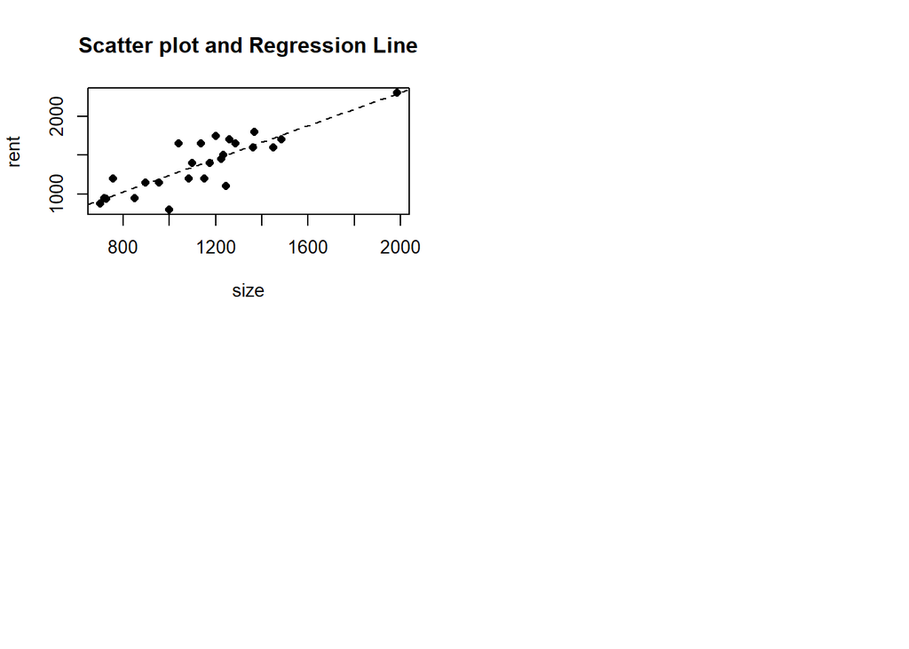

```r
par(mfrow=c(2,2))
plot(rent~size, pch=16)
abline(model1,lty=2)
title( "Scatter plot and Regression Line")
```

### Residual Plot

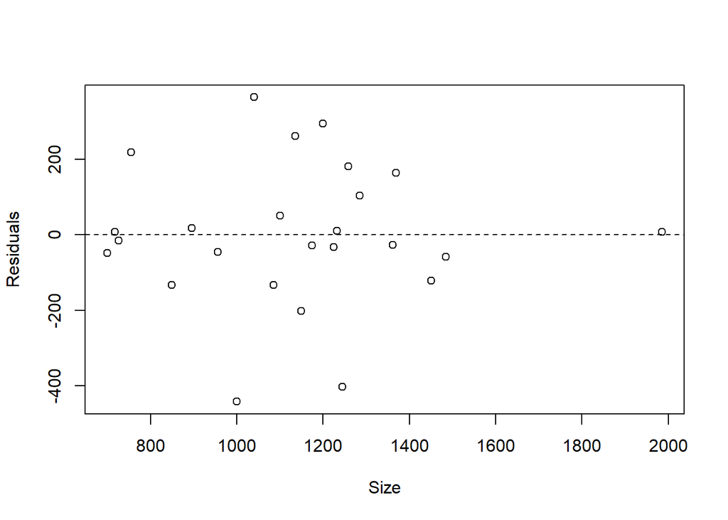

```
## integer(0)
```

```r
rs <- model1$resid
fv <- model1$fitted
plot(rs~size, xlab="Size", ylab="Residuals")+
abline(h=0,lty=2)
```

From the residual plot, there is no obvious pattern observed.

### Normal QQ-Plot

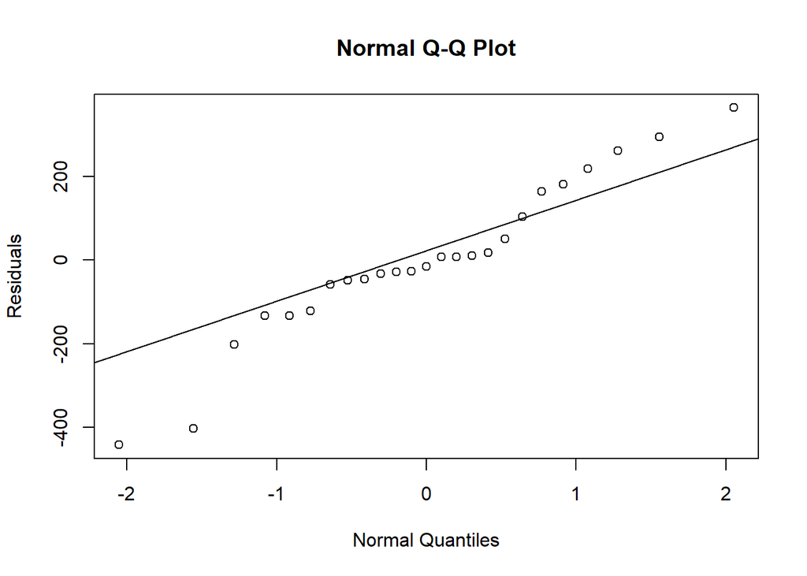

```r
qqnorm(rs,ylab="Residuals",xlab="Normal Quantiles")
qqline(rs)
```

```r
par(mfrow=c(1,1))
```

From the normal QQ-plot, we observe that the residuals are close to the fitted line, showing signs of normality. So we try to validate this with the KS test.

### KS Test

```r
ks.test(rs, "pnorm", mean(rs), sd(rs))
```

```
##
##  One-sample Kolmogorov-Smirnov test
##
## data:  rs
## D = 0.1413, p-value = 0.6493
## alternative hypothesis: two-sided
```

Since the $p$-value from the KS test is $0.6493$, we do not reject the null and conclude that there is no evidence against normality assumption.

## Predicting The Monthly Rental Cost With 1000 Square Feet (Size)

```r
model1$coefficients[1] + 1000*model1$coefficients
```

```
## (Intercept)        size
##  177297.941    1242.265
```

So the predicted cost is $\$1242.265$.

## Recommendation of Apartment

Your friends Jim and Jennifer are considering signing a lease for an apartment in this residential neighborhood. They are trying to decide between two apartments, one with $1000$ square feet, for a monthly rent of $\$1275$, and the other with $1200$ square feet, for a monthly rent of $\$1425$. What would you recommend to them? Why?

```r
# predicted value for 1200 size
model1$coefficients[1] + 1200*model1$coefficients
```

```
## (Intercept)        size
##  212722.105    1455.294
```

Since the predicted value for an apartment with $1000$ square feet is $\$1242.265 < \$1275$ (current cost) and for an apartment with $1200$ square feet is $\$1455.294 > \$1425$ (current cost), the $1200$ square feet apartment is a better option as its cost is lower than its estimated cost.